# IDS Midterm Notes 20/12/2025

## Lecture 2 (13/10/2025)

- **Overview**
  - Vectors
  - names()
  - Data frame
  - Indexing
  - If..else statements
  - For loop
  - Tidyverse
  - select()
  - filter()
  - mutate()
  - arrange()

Vector holds same type of data in array (numbers, expressions, logical values, or character strings)

Elements must be comma-separated and created through function c()

```r
codes <- c(380,124,818)
codes
```

```
## [1] 380 124 818
```

```r
country <- c("Italy", "Canada", "Egypt")
country
```

```
## [1] "Italy"  "Canada" "Egypt"
```

We can create various vectors:

```r
c(1:10) # integers 1-10
```

```
##  [1]  1  2  3  4  5  6  7  8  9 10
```

```r
c(1:5,7,9) # integers 1-5 and 7 and 9
```

```
## [1] 1 2 3 4 5 7 9
```

```r
c(1:5)*2-1 # odd numbers from 1-9
```

```
## [1] 1 3 5 7 9
```

names() function allows you to label or name entries of a vector

```r
names(codes) <- country
codes
```

```
##  Italy Canada  Egypt
##    380    124    818
```

Data frame is a list of vectors of equal length, used for storing data tables

```r
n = c(2, 3, 5)
s = c("aa", "bb", "cc")
b = c(TRUE, FALSE, TRUE)
df = data.frame(n, s, b)
df
```

| n | s | b |
| --- | --- | --- |
| 2 | aa | TRUE |
| 3 | bb | FALSE |
| 5 | cc | TRUE |

[Indexing] To access an element of a vector or data frame, we can use square brackets

Index is a position in a vector or data frame, and in R it always starts at 1

```r
codes[2]
```

```
## Canada
##    124
```

```r
df[2,2] # retrieves element in 2nd row and 2nd column
```

```
## [1] "bb"
```

```r
df[,2] # retrieves entirety of 2nd column
```

```
## [1] "aa" "bb" "cc"
```

```r
df[2,] # retrieves entirety of 2nd row
```

|  | n | s | b |
| --- | --- | --- | --- |
| 2 | 3 | bb | FALSE |

If…else statements are conditional statements that take in a condition and run a specific code depending on if that condition is met or now

We can “nest” if…else statements several times

We can also use a for loop to repeatedly apply an operation but just change the index. In this case, we are indexing over the vector x.

```r
x <- c(25000, 125000, 190000) # input annual income
for (y in x) {
  if(y < 37701) {
    print("This person falls in the basic rate tax band")
    }
  else if(y < 125140) {
    print("This person falls in the higher rate tax band")
    }
  else {
    print("This person falls in the highest tax band")
    }
}
```

```
## [1] "This person falls in the basic rate tax band"
## [1] "This person falls in the higher rate tax band"
## [1] "This person falls in the highest tax band"
```

Tidyverse is a collection of packages helpful for working with tidy data

```r
library(tidyverse)
```

We say a data table is in tidy format if each row represents one observation and columns represent different variables available for each observation

The following is a tidy data table

```r
fertility_rate <- data.frame (
  Year = c(1960, 1961, 1962),
  Fertility_rate_UK = c(2.62, 2.68, 2.75),
  Fertility_rate_South_Korea = c(6.04, 5.89, 5.75)
)
fertility_rate
```

| Year | Fertility_rate_UK | Fertility_rate_South_Korea |
| --- | --- | --- |
| 1960 | 2.62 | 6.04 |
| 1961 | 2.68 | 5.89 |
| 1962 | 2.75 | 5.75 |

We can manipulate a data frame using verbs such as select, filter, mutate, and arrange

- select() allows you to select particular columns from a data frame

```r
subdata <- select(fertility_rate, Year,
Fertility_rate_South_Korea)
subdata
```

| Year | Fertility_rate_South_Korea |
| --- | --- |
| 1960 | 6.04 |
| 1961 | 5.89 |
| 1962 | 5.75 |

- filter() allows you to filter out data that meet a particular criteria (e.g., NA values, values <X, etc.)

```r
filter(subdata, Fertility_rate_South_Korea < 6)
```

| Year | Fertility_rate_South_Korea |
| --- | --- |
| 1961 | 5.89 |
| 1962 | 5.75 |

- mutate() creates new columns that are functions of existing variables. It can also modify (if the name is the same as an existing column) and delete columns (by setting their value to NULL)

lag() is a function that lags a variable by one

```r
fertility_rate <-
  mutate(fertility_rate,rate_change_UK =
           (Fertility_rate_UK - lag(Fertility_rate_UK))/lag(Fertility_rate_UK)*100)
fertility_rate
```

| Year | Fertility_rate_UK | Fertility_rate_South_Korea | rate_change_UK |
| --- | --- | --- | --- |
| 1960 | 2.62 | 6.04 | NA |
| 1961 | 2.68 | 5.89 | 2.290076 |
| 1962 | 2.75 | 5.75 | 2.611940 |

To delete a column using mutate, we use the following:

```r
fertility_rate<- mutate(fertility_rate, rate_change_UK = NULL)
```

- arrange allows you to sort a data frame by a particular column (default is low to high)

```r
arrange(subdata, Fertility_rate_South_Korea)
```

| Year | Fertility_rate_South_Korea |
| --- | --- |
| 1962 | 5.75 |
| 1961 | 5.89 |
| 1960 | 6.04 |

## Tutorial 2 (16/10/2025)

- **Overview**
  - Parts of a function
  - Plotting graph example
  - setwd()
  - read.csv()
  - head()
  - is.na()
  - sum()
  - colSums()
  - na.omit()
  - nrow()
  - Vectorized operations
  - select()
  - filter()
  - mutate()
  - arrange()
  - desc()
  - If..else statement
  - For loop
  - Comparison (==,!=,>,<,>=,<=)

### Tutorial Code

Goals: * tidyverse: select, filter, mutate, arrange * data processing (removing NA values) * user-defined functions (if..else, for loops) * %>% pipe operator

Parts of a function: name, arguments, and body

```r
# name <- function(arguments) {
#
# }
```

Load required library for plotting:

```r
library(plotrix)
```

Explore plotting graphs and making functions

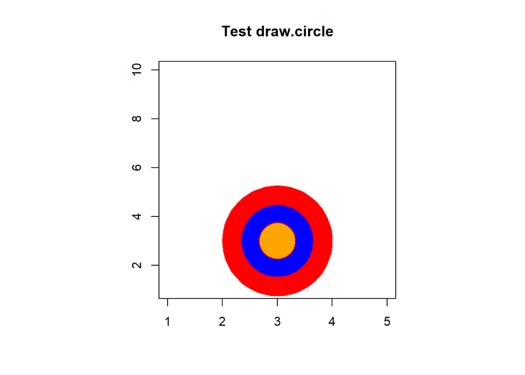

```r
# Takes in variables x and y, which represent the (x,y) coordinates of the circle's center
# Vector c(1,0.66,0.33) represents radii of three circles
# Colour of circumference is red
# c("red","blue","orange") defines colours filling in circles
# lty=1 defines line types for circumference
# lwd=1 means line width is 1
circle <- function(x,y){
  draw.circle(x,y,c(1,0.66,0.33),border="red",
col=c("red","blue","orange"),lty=1,lwd=1)
}

# Defines square plotting region
par(pty="s")

# creates empty plot
# 1:5 sequence for x-axis labels
# seq(1,10,length=5) for y-axis labels
# No x- and y-axis titles
# type=n creates empty plot
# Title of "Test draw.circle"
plot(1:5, seq(1,10,length=5),
     type="n", xlab="", ylab="",
     main="Test draw.circle")

# Draws circle in plot
circle(3,3)
```

Question mark shows available arguments

```r
# ?draw.circle
```

Create extended version of circle function that has default border and fill colours:

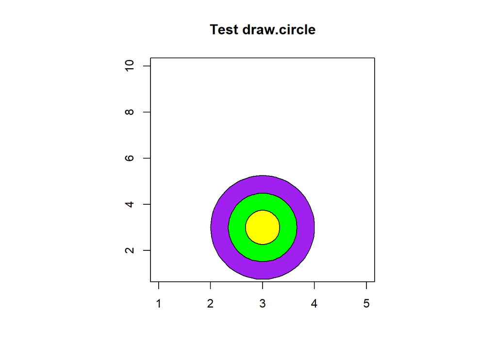

```r
circle_ext <- function(x,y,
                       border_colour = 'red', # default border colour
                       colour = c('red', 'blue', 'orange')){ # default fill colours
  # When circle_ext() is called, this line is executed immediately.
  # The values of 'border_colour' and 'colour' depend on what was passed
  # in the function call. If nothing was passed, the default values above are used.
  draw.circle(x,y,c(1,0.66,0.33),
              border=border_colour, # border colour passed by the user
              col=colour, # fill colours passed by the user
              lty=1,
              lwd=1)
}

par(pty = "s") # keep the plotting region square-shaped

# Create empty plot again
plot(1:5, seq(1,10,length=5),
     type="n", xlab="", ylab="",
     main="Test draw.circle")

# This is the *function call* — where the function is actually executed.
# At this moment, R substitutes x=3, y=3, border_colour='black',
# and colour=c('purple','green','yellow'), and runs the code inside.

circle_ext(3, 3,
           border_colour = 'black',
           colour = c("purple", "green", "yellow"))
```

We load the dataset required for next step:

read.csv() reads data stored in a CSV to a data frame

```r
# Sets working directory
setwd("C:/Users/slee7/OneDrive - Imperial College London/Introduction to Data Science/Week 2")
uk_gdp_and_weeklyWage_na <- read.csv("data/uk_gdp_and_weeklyWage_na.csv")
head(uk_gdp_and_weeklyWage_na)
```

|  | Year | Weekly_pay | GDP_m |
| --- | --- | --- | --- |
| 1 | 2000 | 296 | 1627447 |
| 2 | 2001 | 311 | 1662558 |
| 3 | 2002 | 323 | 1691998 |
| 4 | 2003 | 334 | 1744840 |
| 5 | 2004 | 346 | 1785756 |
| 6 | 2005 | 360 | 1833406 |

is.na() function returns vector (TRUE/FALSE) fo the same length and shape as the input sum() function adds up values (counts TRUE=1 and FALSE=0) Check how many missing values there are in total:

```r
sum(is.na(uk_gdp_and_weeklyWage_na))
```

```
## [1] 6
```

We can use colSums() to sum across the columns:

```r
colSums(is.na(uk_gdp_and_weeklyWage_na))
```

```
##       Year Weekly_pay      GDP_m
##          0          3          3
```

na.omit() removes all rows that contain at least one NA value

```r
uk_gdp_and_weeklyWage_no_NA <- na.omit(uk_gdp_and_weeklyWage_na)
```

nrow() function returns number of rows in data frame

Check how many rows were removed:

```r
nrow(uk_gdp_and_weeklyWage_na) - nrow(uk_gdp_and_weeklyWage_no_NA)
```

```
## [1] 5
```

Confirm that there are no missing values left:

```r
sum(is.na(uk_gdp_and_weeklyWage_no_NA))
```

```
## [1] 0
```

Exercise 1. Write a function compute_s_n that for any given n computes the sum $S(n) = 1^2 + 2^2 + \dots + n^2$. Report the value of the sum when $n=10$.

1. First approach using loops

```r
compute_s_n <- function(n) {
  sum_squares <- 0

  for(i in 1:n){
    sum_squares <- sum_squares +(i^2)
  }

  return(sum_squares)
}

result <- compute_s_n(10)
print(result)
```

```
## [1] 385
```

2. Second approach using vectorized approach

```r
compute_s_n <- function(n) {
  sum_squares <- sum((1:n)^2)

  return(sum_squares)
}

# Compute S_n for n = 10
result <- compute_s_n(10)
print(result)
```

```
## [1] 385
```

#### Exercise 1: Calculating GDP growth rate and classifying weekly wage levels

GDP Growth Rate is calculated using the formula:

$$\text{GDP growth rate} = \frac{\text{GDP this year} - \text{GDP last
year}}{\text{GDP last year}} \times 100$$

```r
# Step 1: Load the dataset
setwd("C:/Users/slee7/OneDrive - Imperial College London/Introduction to Data Science/Week 2")
uk_gdp_and_weeklyWage <- read.csv("data/uk_gdp_and_weeklyWage.csv")

# Step 2: Add two new columns
uk_gdp_and_weeklyWage <- uk_gdp_and_weeklyWage %>%
  mutate(
    # GDP_growth_rate: how much GDP changed since last year, in %
    # lag(GDP_m) gets the previous year's GDP
    GDP_growth_rate = (GDP_m - lag(GDP_m)) / lag(GDP_m) * 100,
         # weeklyWageLevel: TRUE if Weekly_pay > 500, FALSE otherwise
         weeklyWageLevel = Weekly_pay>500)

head(uk_gdp_and_weeklyWage)
```

|  | Year | Weekly_pay | GDP_m | GDP_growth_rate | weeklyWageLevel |
| --- | --- | --- | --- | --- | --- |
| 1 | 2000 | 296 | 1627447 | NA | FALSE |
| 2 | 2001 | 311 | 1662558 | 2.157428 | FALSE |
| 3 | 2002 | 323 | 1691998 | 1.770765 | FALSE |
| 4 | 2003 | 334 | 1744840 | 3.123053 | FALSE |
| 5 | 2004 | 346 | 1785756 | 2.344971 | FALSE |
| 6 | 2005 | 360 | 1833406 | 2.668338 | FALSE |

#### Exercise 2: Working with Leap Years

To determine whether a year is a leap year, we use the following rules:

1. The year must be divisible by 4 → e.g., 2016, 2020, 2024
2. But if the year is also divisible by 100, it is not a leap year → e.g., 1900, 2100
3. However, if it is divisible by 400, it is a leap year → e.g., 2000, 2400

Loop through each row of the dataset and check if leap year

rbind() function stacks two data frames by row

```r
leap_year_subset <- NULL
for (i in 1:nrow(uk_gdp_and_weeklyWage)) {
  # Extract year value for current row
  year_num <- uk_gdp_and_weeklyWage$Year[i]

  # Check if it is a leap year

  # If year is divisible by 100, check if it is also divisible by 400
  if (year_num %% 100 == 0) {

    # If divisible by 400, it is a leap year
    if (year_num %% 400 == 0) {
      leap_year_subset <- rbind(leap_year_subset, uk_gdp_and_weeklyWage[i, ])
    }
  }

  # Otherwise, check if divisible by 4
  else if (year_num %% 4 == 0) {
    leap_year_subset <- rbind(leap_year_subset, uk_gdp_and_weeklyWage[i, ])
  }

  # If both conditions fail, it is not a leap year
  else {
    print(paste(year_num, "is not a leap year"))
  }
}
```

```
## [1] "2001 is not a leap year"
## [1] "2002 is not a leap year"
## [1] "2003 is not a leap year"
## [1] "2005 is not a leap year"
## [1] "2006 is not a leap year"
## [1] "2007 is not a leap year"
## [1] "2009 is not a leap year"
## [1] "2010 is not a leap year"
## [1] "2011 is not a leap year"
## [1] "2013 is not a leap year"
## [1] "2014 is not a leap year"
## [1] "2015 is not a leap year"
## [1] "2017 is not a leap year"
## [1] "2018 is not a leap year"
## [1] "2019 is not a leap year"
## [1] "2021 is not a leap year"
## [1] "2022 is not a leap year"
```

```r
leap_year_subset
```

|  | Year | Weekly_pay | GDP_m | GDP_growth_rate | weeklyWageLevel |
| --- | --- | --- | --- | --- | --- |
| 1 | 2000 | 296 | 1627447 | NA | FALSE |
| 5 | 2004 | 346 | 1785756 | 2.3449715 | FALSE |
| 9 | 2008 | 405 | 1918064 | -0.1543444 | FALSE |
| 13 | 2012 | 434 | 1923551 | 1.4484567 | FALSE |
| 17 | 2016 | 464 | 2114406 | 2.1652062 | FALSE |
| 21 | 2020 | 516 | 1991439 | -11.0308585 | TRUE |

### Additional Files

We can compare values and variables. output is either TRUE or FALSE boolean/logical values

```r
5 == 5
```

```
## [1] TRUE
```

```r
5 != 5
```

```
## [1] FALSE
```

```r
5 > 6
```

```
## [1] FALSE
```

```r
5 >= 5
```

```
## [1] TRUE
```

```r
4 < 5
```

```
## [1] TRUE
```

```r
4 <= 5
```

```
## [1] TRUE
```

select() function

```r
uk_gdp_and_weeklyWage %>%
  select(Year, Weekly_pay) %>%
  head()
```

|  | Year | Weekly_pay |
| --- | --- | --- |
| 1 | 2000 | 296 |
| 2 | 2001 | 311 |
| 3 | 2002 | 323 |
| 4 | 2003 | 334 |
| 5 | 2004 | 346 |
| 6 | 2005 | 360 |

filter() function

```r
uk_gdp_and_weeklyWage %>%
  select(Year, Weekly_pay) %>%
  filter(Year %% 4 == 0,
         Year %% 100 != 0 |
           Year %% 400 ==0 )
```

| Year | Weekly_pay |
| --- | --- |
| 2000 | 296 |
| 2004 | 346 |
| 2008 | 405 |
| 2012 | 434 |
| 2016 | 464 |
| 2020 | 516 |

mutate() function

```r
uk_gdp_and_weeklyWage <- uk_gdp_and_weeklyWage %>%
  mutate(GDP_growth_rate =
           (GDP_m - lag(GDP_m)) / lag(GDP_m) * 100)
```

arrange() function

Default is sorting in ascending order. To sort by descending order, specify arrange(desc())

```r
uk_gdp_and_weeklyWage %>%
  arrange(desc(GDP_growth_rate))
```

| Year | Weekly_pay | GDP_m | GDP_growth_rate | weeklyWageLevel |
| --- | --- | --- | --- | --- |
| 2021 | 542 | 2142738 | 7.5974710 | TRUE |
| 2022 | 571 | 2230625 | 4.1016214 | TRUE |
| 2014 | 443 | 2021225 | 3.1997026 | FALSE |
| 2003 | 334 | 1744840 | 3.1230533 | FALSE |
| 2005 | 360 | 1833406 | 2.6683377 | FALSE |
| 2007 | 390 | 1921029 | 2.5634605 | FALSE |
| 2017 | 473 | 2166073 | 2.4435704 | FALSE |
| 2010 | 420 | 1876058 | 2.4300729 | FALSE |
| 2015 | 453 | 2069595 | 2.3931032 | FALSE |
| 2004 | 346 | 1785756 | 2.3449715 | FALSE |

[output cut: 13 more lines]

## Lecture 3 (20/10/2025)

- **Overview**
  - Tidy format
  - pull() / $
  - Dot operator
  - case_when()
  - between()
  - group_by()
  - ungroup()
  - summarise()
  - n()
  - mean()

Tidy format if:

1. each row represents one observation
2. each column represents the different variables available for each of these observations
3. each value is a cell with each cell being a single value

Load required package

```r
library(nycflights13)
```

We will use the flights dataset within the package.

We can sort first by the year, then within each year by month, then within each month by day, and then from the most delay to the least delay

```r
flights %>%
  arrange(year, month, day, desc(dep_delay)) %>%
  head()
```

| year | month | day | dep_time | sched_dep_time | dep_delay | arr_time | sched_arr_time | arr_delay | carrier | flight | tailnum | origin | dest | air_time | distance | hour | minute | time_hour |
| --- | --- | --- | --- | --- | --- | --- | --- | --- | --- | --- | --- | --- | --- | --- | --- | --- | --- | --- |
| 2013 | 1 | 1 | 848 | 1835 | 853 | 1001 | 1950 | 851 | MQ | 3944 | N942MQ | JFK | BWI | 41 | 184 | 18 | 35 | 2013-01-01 18:00:00 |
| 2013 | 1 | 1 | 2343 | 1724 | 379 | 314 | 1938 | 456 | EV | 4321 | N21197 | EWR | MCI | 222 | 1092 | 17 | 24 | 2013-01-01 17:00:00 |
| 2013 | 1 | 1 | 1815 | 1325 | 290 | 2120 | 1542 | 338 | EV | 4417 | N17185 | EWR | OMA | 213 | 1134 | 13 | 25 | 2013-01-01 13:00:00 |
| 2013 | 1 | 1 | 2205 | 1720 | 285 | 46 | 2040 | 246 | AA | 1999 | N5DNAA | EWR | MIA | 146 | 1085 | 17 | 20 | 2013-01-01 17:00:00 |
| 2013 | 1 | 1 | 1842 | 1422 | 260 | 1958 | 1535 | 263 | EV | 4633 | N18120 | EWR | BTV | 46 | 266 | 14 | 22 | 2013-01-01 14:00:00 |
| 2013 | 1 | 1 | 2115 | 1700 | 255 | 2330 | 1920 | 250 | 9E | 3347 | N924XJ | JFK | CVG | 115 | 589 | 17 | 0 | 2013-01-01 17:00:00 |

pull() is similar to $, where it gets a specific variable (column) from a data frame

```r
# Equivalent to head(flights$dep_delay)
flights %>%
  pull(dep_delay) %>%
  head(10)
```

```
##  [1]  2  4  2 -1 -6 -4 -5 -3 -3 -2
```

Dot operator lets the pipe move the value into a specified argument.

```r
exponent <- function(x,y){
  x^y
  }
x <- 2
y <- 3
# Computes 3^2
y %>% exponent(x)
```

```
## [1] 9
```

```r
#Computes 2^3
y %>% exponent(x,.)
```

```
## [1] 8
```

case_when() function outputs any number of values depending on the conditional statement

```r
x <- c(-2, -1, 0, 1, 2)
case_when(x < 0 ~ "Negative",
          x > 0 ~ "Positive",
          TRUE ~ "Zero")
```

```
## [1] "Negative" "Negative" "Zero"     "Positive" "Positive"
```

We can use case_when() with mutate to create new column with data depending on a conditional statement with an existing variable

```r
flights %>%
  filter(!is.na(dep_delay)) %>%
  mutate(group= case_when(
    dep_delay < 0 ~ "Early departure",
    dep_delay == 0 ~ "On time",
    dep_delay > 60 ~ "Delayed more than 1 hour",
    TRUE ~ "Delayed up to 1 hour")) %>%
  select(dep_delay,group) %>%
  head()
```

| dep_delay | group |
| --- | --- |
| 2 | Delayed up to 1 hour |
| 4 | Delayed up to 1 hour |
| 2 | Delayed up to 1 hour |
| -1 | Early departure |
| -6 | Early departure |
| -4 | Early departure |

between() allows to check if a value falls inside an interval

between(x,a,b) does the same as x >= a & x <= b

```r
flights %>%
  filter(!is.na(dep_delay)) %>%
  mutate(group= case_when(
    dep_delay < 0 ~ "Early departure",
    between(dep_delay,0,10)~ "On time up to 10 mins",
    dep_delay > 10 ~ "Delayed more than 10 mins")) %>%
  select(dep_delay,group) %>%
  head()
```

| dep_delay | group |
| --- | --- |
| 2 | On time up to 10 mins |
| 4 | On time up to 10 mins |
| 2 | On time up to 10 mins |
| -1 | Early departure |
| -6 | Early departure |
| -4 | Early departure |

group_by() allows you to group a data frame by a particular categorical variable

Any subsequent operation conduct will work on the group

It is good practice to ungroup() the data frame after conducting the grouped operation

We can group the data by each date and calculate the average delay by using summarise():

```r
flights %>%
  group_by(year, month, day) %>%
  summarise(avg_delay = mean(dep_delay, na.rm = TRUE)) %>%
  ungroup() %>%
  head()
```

| year | month | day | avg_delay |
| --- | --- | --- | --- |
| 2013 | 1 | 1 | 11.548926 |
| 2013 | 1 | 2 | 13.858824 |
| 2013 | 1 | 3 | 10.987832 |
| 2013 | 1 | 4 | 8.951595 |
| 2013 | 1 | 5 | 5.732218 |
| 2013 | 1 | 6 | 7.148014 |

Another useful summary is n(), which returns the number of rows in each group

```r
flights %>%
  group_by(month) %>%
  summarise(
    avg_delay = mean(dep_delay, na.rm = TRUE),
    nrows = n()) %>%
  head()
```

| month | avg_delay | nrows |
| --- | --- | --- |
| 1 | 10.03667 | 27004 |
| 2 | 10.81684 | 24951 |
| 3 | 13.22708 | 28834 |
| 4 | 13.93804 | 28330 |
| 5 | 12.98686 | 28796 |
| 6 | 20.84633 | 28243 |

### Check your understanding

Suppose we have the following data frame:

```r
df <- data.frame(
  x = 1:5,
  y = c("a", "b", "a", "a", "b"),
  z = c("K", "K", "L", "L", "K")
)
df
```

| x | y | z |
| --- | --- | --- |
| 1 | a | K |
| 2 | b | K |
| 3 | a | L |
| 4 | a | L |
| 5 | b | K |

Visualize what the following outputs might be:

```r
df %>%
  group_by(y)
```

| x | y | z |
| --- | --- | --- |
| 1 | a | K |
| 2 | b | K |
| 3 | a | L |
| 4 | a | L |
| 5 | b | K |

```r
df %>%
  arrange(y)
```

| x | y | z |
| --- | --- | --- |
| 1 | a | K |
| 3 | a | L |
| 4 | a | L |
| 2 | b | K |
| 5 | b | K |

```r
df %>%
  group_by(y) %>%
  summarise(
    # mean() calculates the mean of all the values
    mean_x = mean(x)
  )
```

| y | mean_x |
| --- | --- |
| a | 2.666667 |
| b | 3.500000 |

```r
df %>%
  group_by(y,z) %>%
  summarise(
    mean_x = mean(x)
  )
```

[output not shown]

| y | z | mean_x |
| --- | --- | --- |
| a | K | 1.0 |
| a | L | 3.5 |
| b | K | 3.5 |

```r
df %>%
  group_by(y,z) %>%
  mutate(
    mean_x = mean(x)
  )
```

| x | y | z | mean_x |
| --- | --- | --- | --- |
| 1 | a | K | 1.0 |
| 2 | b | K | 3.5 |
| 3 | a | L | 3.5 |
| 4 | a | L | 3.5 |
| 5 | b | K | 3.5 |

## Tutorial 3 (23/10/2025)

- **Overview**
  - dplyr package
  - Ways to access columns: $, [[]], [, “col”]
  - min()
  - max()
  - Turn data frame columns into vectors
  - seq() with dates
  - format()
  - quantile()
  - cut()
  - sd()
  - tail()
  - summary()
  - parse_number()

### Tutorial Code

Load required package and sample data frame

```r
library(dplyr)

students <- data.frame(
  name = c("Alice", "Bob", "Chloe", "Daniel", "Emma"),
  age = c(21, 22, 20, 23, 21),
  score = c(85, 90, 78, 92, 88)
)
```

You can access the column in different ways:

```r
students$name # Using the $ operator
```

```
## [1] "Alice"  "Bob"    "Chloe"  "Daniel" "Emma"
```

```r
students[["age"]]
```

```
## [1] 21 22 20 23 21
```

```r
students[, "score"]
```

```
## [1] 85 90 78 92 88
```

min() function finds the minimum value of the data

max() function finds the maximum value of the data

```r
students %>%
  summarise(
    avg_score = mean(score),
    min_score = min(score),
    max_score = max(score)
)
```

| avg_score | min_score | max_score |
| --- | --- | --- |
| 86.6 | 78 | 92 |

Sometimes datasets include dates. Here is an example of creating one using seq() and extracting its year using mutate() and format().

format() takes in an object and POSIX-style format codes for Date objects to extract a specific part of the object as a character (string)

- %Y - 4-digit year
- $m - month(01-12)
- %d - day

```r
example_dates <- data.frame(
  Date = seq(as.Date("2020-01-01"),
             by = "month",
             length.out = 6)
)

example_dates %>%
  mutate(Year = format(Date, "%Y"))
```

| Date | Year |
| --- | --- |
| 2020-01-01 | 2020 |
| 2020-02-01 | 2020 |
| 2020-03-01 | 2020 |
| 2020-04-01 | 2020 |
| 2020-05-01 | 2020 |
| 2020-06-01 | 2020 |

You can extract a single column as vector using pull() or the dot operator

```r
mtcars %>%
  pull(mpg) %>%
  head()
```

```
## [1] 21.0 21.0 22.8 21.4 18.7 18.1
```

```r
mtcars %>%
  .$mpg %>%
  head()
```

```
## [1] 21.0 21.0 22.8 21.4 18.7 18.1
```

### Additional Files

cut() function used to cut a range of values into bins and specify labels for each bin

```r
vec <- c(0:100)
cut(vec,
    # number of breaks to make or vector of break points
    c(0,20,40,60,80,100),
    # whether to include lowest break point
    include.lowest = TRUE,
    # labels = NULL produces interval bins,
    # labels = FALSE produces integer category starting at 1,
    # and you can also assign your own labels with labels = c()
    labels = FALSE)
```

```
##   [1] 1 1 1 1 1 1 1 1 1 1 1 1 1 1 1 1 1 1 1 1 1 2 2 2 2 2 2 2 2 2 2 2 2 2 2 2 2
##  [38] 2 2 2 2 3 3 3 3 3 3 3 3 3 3 3 3 3 3 3 3 3 3 3 3 4 4 4 4 4 4 4 4 4 4 4 4 4
##  [75] 4 4 4 4 4 4 4 5 5 5 5 5 5 5 5 5 5 5 5 5 5 5 5 5 5 5 5
```

quantile() function produces sample quantiles corresponding to the given probabilities. The smallest observation corresponds to a probability of 0 and the largest to a probability of 1.

```r
vec <- c(0:50)
quantile(vec,
         # vector of probabilities
         # seq(0,1,0.25) = c(0,0.25,0.5,0.75,1)
         # these are the quartiles (0%, 25%, 50%, 75%, and 100%)
         probs = seq(0, 1, 0.25),
         # types of 1-9 quantile algorithms
         # default is 7
         type = 7)
```

```
##   0%  25%  50%  75% 100%
##  0.0 12.5 25.0 37.5 50.0
```

By making the quantiles the break points and combining with cut, we can categorize different numerical values into their respective quartiles.

```r
uk_gdp_and_weeklyWage <- uk_gdp_and_weeklyWage %>%
  mutate(
    GDP_growth_rate = (GDP_m - lag(GDP_m)) / lag(GDP_m) * 100
    )

uk_gdp_and_weeklyWage <- uk_gdp_and_weeklyWage %>%
  mutate(GDP_growth_rate_Quartile = cut(GDP_growth_rate,
                                        quantile(GDP_growth_rate,
                                                 probs = seq(0, 1, 0.25),
                                                 type = 7,
                                                 na.rm = T),
                                        include.lowest = T,
                                        labels = F)
)

uk_gdp_and_weeklyWage %>%
  arrange(GDP_growth_rate) %>%
  head()
```

|  | Year | Weekly_pay | GDP_m | GDP_growth_rate | weeklyWageLevel | GDP_growth_rate_Quartile |
| --- | --- | --- | --- | --- | --- | --- |
| 1 | 2020 | 516 | 1991439 | -11.0308585 | TRUE | 1 |
| 2 | 2009 | 412 | 1831550 | -4.5104856 | FALSE | 1 |
| 3 | 2008 | 405 | 1918064 | -0.1543444 | FALSE | 1 |
| 4 | 2011 | 427 | 1896087 | 1.0676109 | FALSE | 1 |
| 5 | 2012 | 434 | 1923551 | 1.4484567 | FALSE | 1 |
| 6 | 2019 | 505 | 2238348 | 1.6043087 | TRUE | 1 |

sd() gives the standard deviation of the data

Find mean and standard deviations of data:

```r
uk_gdp_and_weeklyWage %>%
  filter(!is.na(GDP_growth_rate_Quartile)) %>%
  group_by(GDP_growth_rate_Quartile) %>%
  summarise(mean_GDP = mean(GDP_m),
            std_GDP = sd(GDP_m),
            mean_wage = mean(Weekly_pay),
            std_wage = sd(Weekly_pay),
            mean_GDPrate = mean(GDP_growth_rate),
            std_GDPrate = sd(GDP_growth_rate)) %>%
  ungroup()
```

| GDP_growth_rate_Quartile | mean_GDP | std_GDP | mean_wage | std_wage | mean_GDPrate | std_GDPrate |
| --- | --- | --- | --- | --- | --- | --- |
| 1 | 1966507 | 142746.9 | 449.8333 | 48.23864 | -1.929219 | 5.0105580 |
| 2 | 1877827 | 219746.7 | 386.8000 | 75.56917 | 1.922697 | 0.2194566 |
| 3 | 2002378 | 163360.2 | 431.2000 | 51.67882 | 2.355385 | 0.1129757 |
| 4 | 1982311 | 185057.6 | 440.0000 | 97.68316 | 3.875608 | 1.9029328 |

tail() gives the last n number of rows of a data frame

```r
uk_gdp_and_weeklyWage %>%
  arrange(GDP_growth_rate) %>%
  tail(10)
```

|  | Year | Weekly_pay | GDP_m | GDP_growth_rate | weeklyWageLevel | GDP_growth_rate_Quartile |
| --- | --- | --- | --- | --- | --- | --- |
| 14 | 2015 | 453 | 2069595 | 2.393103 | FALSE | 3 |
| 15 | 2010 | 420 | 1876058 | 2.430073 | FALSE | 3 |
| 16 | 2017 | 473 | 2166073 | 2.443570 | FALSE | 3 |
| 17 | 2007 | 390 | 1921029 | 2.563461 | FALSE | 4 |
| 18 | 2005 | 360 | 1833406 | 2.668338 | FALSE | 4 |
| 19 | 2003 | 334 | 1744840 | 3.123053 | FALSE | 4 |
| 20 | 2014 | 443 | 2021225 | 3.199703 | FALSE | 4 |
| 21 | 2022 | 571 | 2230625 | 4.101621 | TRUE | 4 |
| 22 | 2021 | 542 | 2142738 | 7.597471 | TRUE | 4 |
| 23 | 2000 | 296 | 1627447 | NA | FALSE | NA |

summary() gives a generic result summary

```r
GDP_growth_rate_summary <-
  uk_gdp_and_weeklyWage %>%
  summary(GDP_growth_rate, na.rm=T)
GDP_growth_rate_summary
```

```
##       Year        Weekly_pay        GDP_m         GDP_growth_rate
##  Min.   :2000   Min.   :296.0   Min.   :1627447   Min.   :-11.031
##  1st Qu.:2006   1st Qu.:367.0   1st Qu.:1832478   1st Qu.:  1.629
##  Median :2011   Median :427.0   Median :1921029   Median :  2.163
##  Mean   :2011   Mean   :422.8   Mean   :1944407   Mean   :  1.503
##  3rd Qu.:2016   3rd Qu.:468.5   3rd Qu.:2092001   3rd Qu.:  2.533
##  Max.   :2022   Max.   :571.0   Max.   :2238348   Max.   :  7.597
##                                                   NA's   :1
##  weeklyWageLevel GDP_growth_rate_Quartile
##  Mode :logical   Min.   :1.00
##  FALSE:19        1st Qu.:1.25
##  TRUE :4         Median :2.50
##                  Mean   :2.50
##                  3rd Qu.:3.75
##                  Max.   :4.00
##                  NA's   :1
```

parse_number() drops any non-numeric characters before and after the first number

```r
GDP_growth_rate_summary[3,4]
```

```
## [1] "Median :  2.163  "
```

```r
parse_number(GDP_growth_rate_summary[3,4],
             # Makes sure " " (spaces) separate thousands, not "," (commas)
             # parse_number() ignores spaces when parsing
             locale = locale(grouping_mark = " "))
```

```
## [1] 2.163
```